# STAT 408: Week 11

4/5/2022

## Motivation

## Data

Data from the openintro package: [`elmhurst`](http://openintrostat.github.io/openintro/reference/elmhurst.html).

- Family income and gift aid data from a random sample of fifty students in the freshman class of Elmhurst College in Illinois, USA
- Gift aid is financial aid that does not need to be paid back, as opposed to a loan

## Linear model

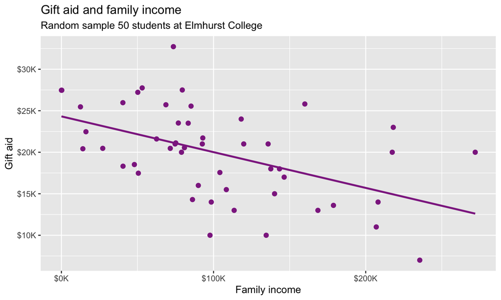

## Interpreting the slope

```r
lm(gift_aid ~ family_income, data = elmhurst)
```

```
##   (Intercept) family_income
##       24.3193       -0.0431
```

For each additional $1,000 of family income, we would expect students to receive a net difference of 1,000 * (-0.0431) = -$43.10 in aid on average, i.e., $43.10 less in gift aid, on average.

…*exactly $43.10 for all students at this school?!*

## Inference

## Statistical inference

… is the process of using sample data to make conclusions about the underlying population the sample came from.

## Estimation

Use data from samples to calculate sample statistics, which can then be used as estimates for population parameters.

- If you want to catch a fish, do you prefer a spear or a net?…
- If you want to estimate a population parameter, do you prefer to report a range of values the parameter might be in, or a single value?
- If we report a point estimate, we probably won’t hit the exact population parameter.
- If we report a range of plausible values we have a good shot at capturing the parameter.

## Confidence intervals

## Confidence intervals

A plausible range of values for the population parameter is a **confidence interval**.

- In order to construct a confidence interval we need to quantify the variability of our sample statistic.
- For example, if we want to construct a confidence interval for a population slope, we need to come up with a plausible range of values around our observed sample slope.
- This range will depend on how precise and how accurate our sample statistic is as an estimate of the population parameter.
- Quantifying this requires a measurement of **how much we would expect the sample statistic to vary from sample to sample**, which is called **sampling variability**.

## Sampling variability

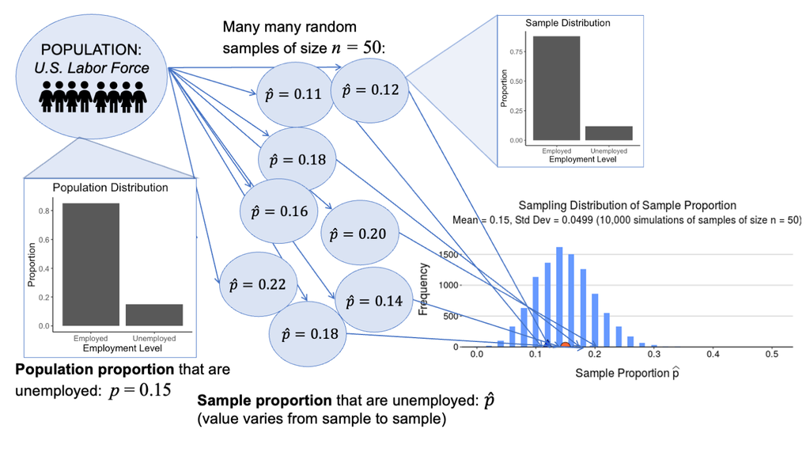

## Quantifying the variability of sample statistics

We can quantify the variability of sample statistics using

- theory: via Central Limit Theorem

```r
summary(lm(gift_aid ~ family_income, data = elmhurst))$coef
```

```
##                  Estimate Std. Error   t value     Pr(>|t|)
## (Intercept)   24.31932901 1.29145027 18.831022 8.281020e-24
## family_income -0.04307165 0.01080947 -3.984621 2.288734e-04
```

or

- simulation: via bootstrapping…

## Bootstrapping

## Bootstrapping

- *“pulling oneself up by one’s bootstraps”*: accomplishing an impossible task without any outside help
- **Impossible task:** estimating a population parameter using data from only the given sample
- **Note:** Notion of saying something about a population parameter using only information from an observed sample is the crux of statistical inference

## Observed sample

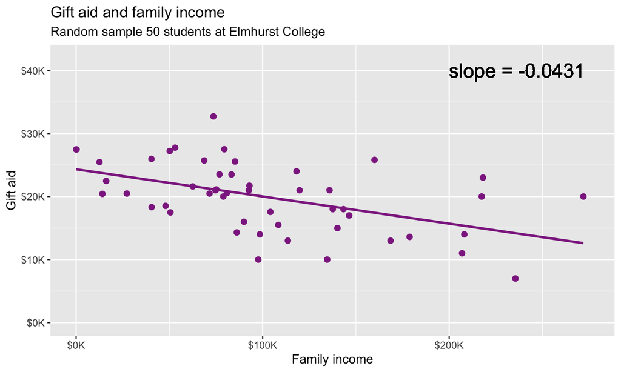

## Bootstrapped “population”

Generated assuming there are more students like the ones in the observed sample…

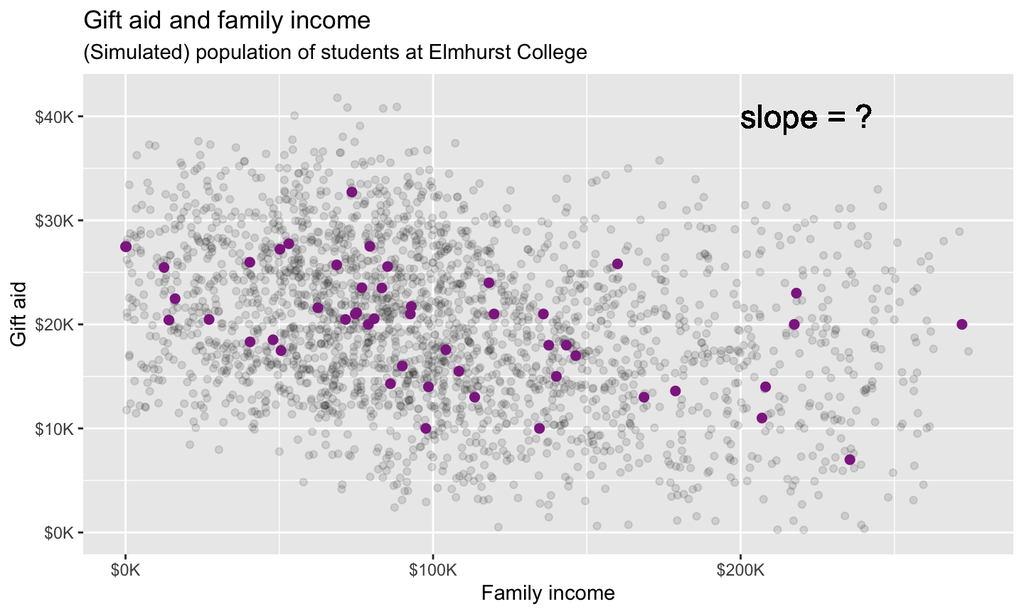

## Bootstrapping scheme

1. Take a bootstrap sample - a random sample taken **with replacement** from the original sample, of the same size as the original sample
2. Calculate the bootstrap statistic - a statistic such as mean, median, proportion, slope, etc. computed on the bootstrap samples
3. Repeat steps (1) and (2) many times to create a bootstrap distribution - a distribution of bootstrap statistics
4. Calculate the bounds of the XX% confidence interval as the middle XX% of the bootstrap distribution

## Bootstrap sample 1

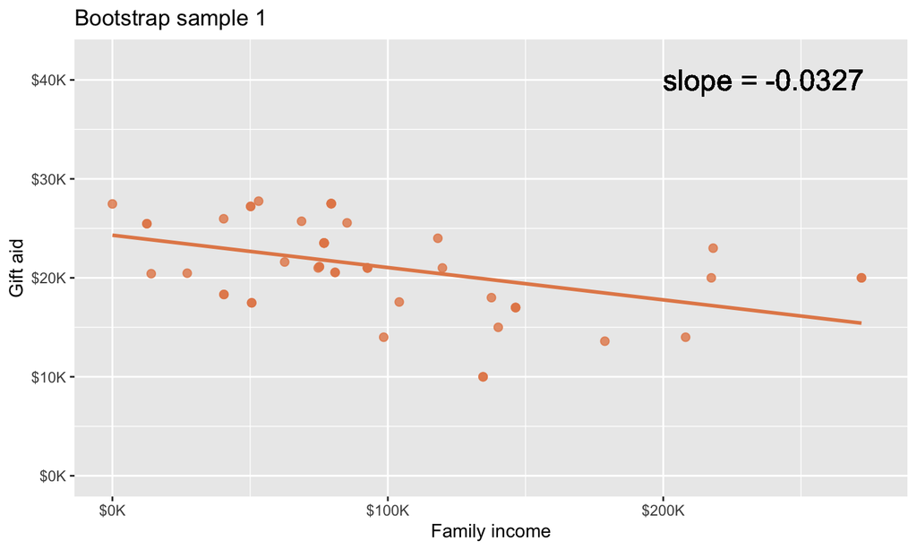

## Bootstrap sample 2

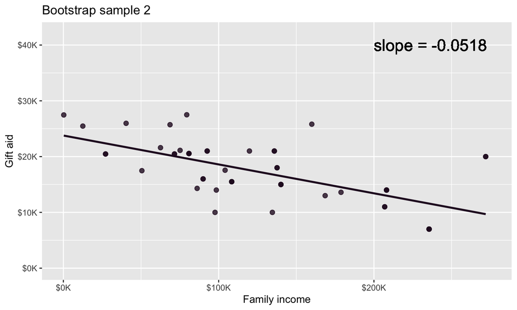

## Bootstrap sample 3

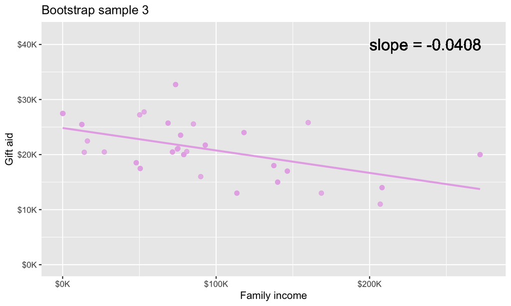

## Bootstrap sample 4

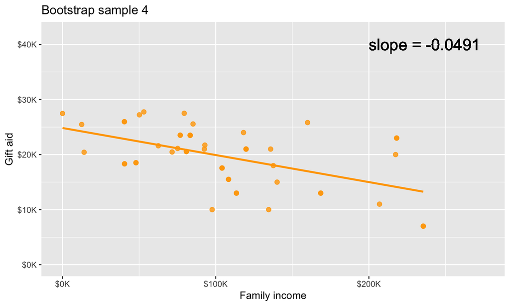

## Bootstrap samples 1–4

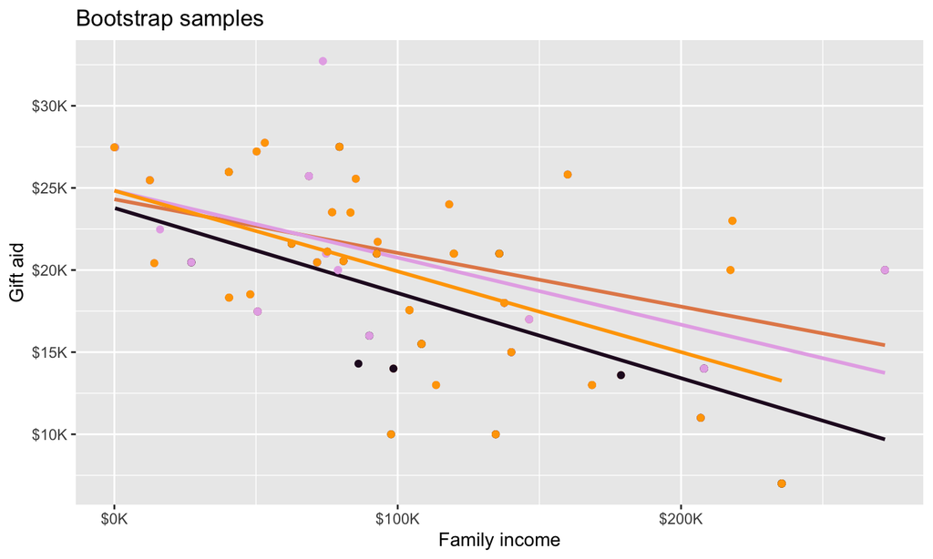

we could keep going…

## Many many samples…

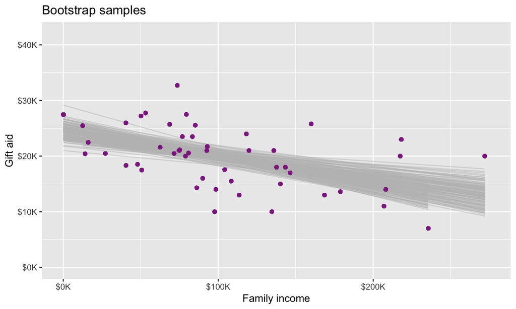

## Slopes of bootstrap samples

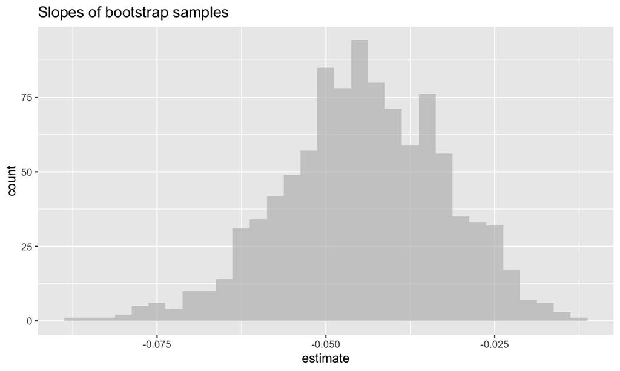

## 95% confidence interval

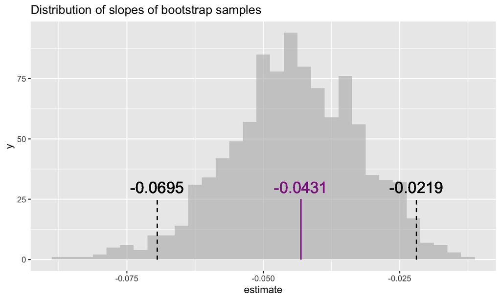

## Interpreting the slope, take two

```
## # A tibble: 2 × 6
##   term           .lower .estimate  .upper .alpha .method
##   <chr>           <dbl>     <dbl>   <dbl>  <dbl> <chr>
## 1 (Intercept)   21.8      24.4    26.8      0.05 percentile
## 2 family_income -0.0695   -0.0445 -0.0219   0.05 percentile
```

**We are 95% confident that** for each additional $1,000 of family income, we would expect students to receive $69.50 to $21.90 less in gift aid, on average.

## Code using **tidymodels** package

```r
# set a seed
set.seed(1234)

# take 1000 bootstrap samples
elmhurst_boot <- bootstraps(elmhurst, times = 1000)

# for each sample
# fit a model and save output in model column
# tidy model output and save in coef_info column
elmhurst_models <- elmhurst_boot %>%
  mutate(
    model = map(splits, ~ lm(gift_aid ~ family_income, data = .)),
    coef_info = map(model, tidy)
  )
```

## Code using **tidymodels** package

```r
# unnest coef_info (for intercept and slope)
elmhurst_coefs <- elmhurst_models %>%
  unnest(coef_info)

# calculate 95% (default) percentile interval
int_pctl(elmhurst_models, coef_info)
```

## Demo/Exercise

Write a function to create a 95% confidence interval for a linear regression slope using bootstrapping from scratch.

## Discussion

Discuss and visualize how you could generate a bootstrapped estimate of sampling variability for…

1. one mean
2. one proportion
3. difference in means

## Demo/Exercise

“Random” sample of 10 2-bedroom apartments for rent in Bozeman, MT in April 2022:

```r
apts <- data.frame(price = c(2349, 3500, 2650, 1250, 1700,
                             2075, 2000, 1900, 2849, 1275))
```

(Data from [apartments.com](https://www.apartments.com/)…. can we assume this is a random sample? From what population?)

Use bootstrapping to estimate the sampling variability of the sample mean.

## Extension

How could we use bootstrapping to calculate a p-value for a test of

\(H_0: \mu = 2000\)

\(H_a: \mu > 2000\),

where \(\mu\) is the “true” mean rent for 2-bedroom apartments in Bozeman.

What if we wanted to test the median rather than the mean?

## Interpreting (frequentist) confidence intervals

A 95% confidence interval for the mean rent of two bedroom apartments in Bozeman was calculated as ($1650.70, $2658.90). Which of the following is a correct interpretation of this interval?

1. 95% of the time, the mean rent of two bedroom apartments in a sample of 10 rentals is between $1650.70 and $2658.90.
2. 95% of all two bedroom apartments in Bozeman have rents between $1650.70 and $2658.90.
3. We are 95% confident that the mean rent of all two bedroom apartments in Bozeman is between $1650.70 and $2658.90.
4. We are 95% confident that the mean rent of two bedroom apartments in this sample is between $1650.70 and $2658.90.

## Reflection

1. What is the difference between a bootstrap distribution and a sampling distribution?
2. Where would you expect a sampling distribution to be centered?
3. Where would you expect a bootstrap distribution to be centered?
4. How should the variability in a sampling distribution of, say, a sample mean, change as the sample size increases? Why?